# AssociationRules

## Reading the transaction file

Our transaction file is given in the “basket” format, which means that each line represents a transaction, with the transaction ID as first column and the next columns being objects contains in this transaction (in this context: buying of each customer).

```r
ttr <- read.transactions("Transactions.txt", format="basket", header=FALSE, sep=" ", cols=1)
```

## First exploration

```r
summary(ttr)
```

```
## transactions as itemMatrix in sparse format with
##  20082 rows (elements/itemsets/transactions) and
##  858 columns (items) and a density of 0.03398038
##
## most frequent items:
## 1104010101 1301120101 1104020101 1103010101 1301120200    (Other)
##      10277       9275       8795       8356       7516     541275
##
## element (itemset/transaction) length distribution:
## sizes
##   1   2   3   4   5   6   7   8   9  10  11  12  13  14  15  16  17  18  19  20
## 326 203 191 180 195 217 193 186 209 226 230 232 275 280 309 326 338 366 424 440
##  21  22  23  24  25  26  27  28  29  30  31  32  33  34  35  36  37  38  39  40
## 449 466 524 548 558 599 590 616 641 647 613 602 639 563 509 543 492 455 510 430
##  41  42  43  44  45  46  47  48  49  50  51  52  53  54  55  56  57  58  59  60
## 363 319 329 255 237 205 194 195 170 151 144 120 100 104  77  84  80  65  43  48
##  61  62  63  64  65  66  67  68  69  70  71  72  73  74  75  76  77  78  79  80
##  50  44  33  31  23  21  19  16  16  18  12  18  12  14   9  11  14   7   6   6
##  81  82  83  84  85  86  87  88  89  90  91  92  93  97  98  99 100 102 104 105
##   7   7   2   4   5   6   6   3   3   5   2   1   1   2   1   2   1   4   1   1
## 106 107 111 113 114 117 118 120 123 124 125 138 145
##   1   1   1   1   3   1   1   1   1   1   1   1   1
##
##    Min. 1st Qu.  Median    Mean 3rd Qu.    Max.
##    1.00   20.00   29.00   29.16   38.00  145.00
##
## includes extended item information - examples:
##       labels
## 1 1101010101
## 2 1101010102
## 3 1101010103
##
## includes extended transaction information - examples:
##   transactionID
## 1           357
## 2           610
## 3           635
```

```r
head(as(ttr, "list"))
```

```
## $`357`
## [1] "1101010101" "1104020101" "1206010101" "1301010101" "1301120101"
## [6] "1302060401"
##
## $`610`
##  [1] "1101060101" "1101090101" "1101110102" "1101150105" "1102010201"
##  [6] "1102010800" "1102030501" "1103010102" "1104020101" "1104020102"
## [11] "1104020401" "1104020501" "1104030103" "1104030105" "1104040101"
## [16] "1104040200" "1205020101" "1205020300" "1205020503" "1205040103"
## [21] "1301020100" "1301030100" "1301040301" "1301060508" "1301110100"
## [26] "1301110301" "1301120200"
##
## $`635`
##  [1] "1101020103" "1101020201" "1101040103" "1102010700" "1103010101"
##  [6] "1104030300" "1104050201" "1104050303" "1104070501" "1205010502"
## [11] "1205010504" "1205010801" "1301010103" "1301020100" "1301050103"
## [16] "1301100106" "1301110301" "1301120101"
##
## $`652`
##  [1] "1101040103" "1101120301" "1101190101" "1102010102" "1102010201"
##  [6] "1102010700" "1103010103" "1104010101" "1203060100" "1301040201"
##
## $`653`
##  [1] "1101230100" "1104010101" "1104020101" "1104020102" "1201070201"
##  [6] "1203010102" "1203110103" "1205010103" "1205010603" "1205010801"
## [11] "1205020503" "1206010101" "1206020101" "1206020304" "1206020401"
## [16] "1209010102" "1301010103"
##
## $`679`
## [1] "1103010101" "1104010101" "1104030101" "1104030200" "1205010402"
## [6] "1205010403" "1301020100"
```

### What is the most frequent item ? (without filtering)

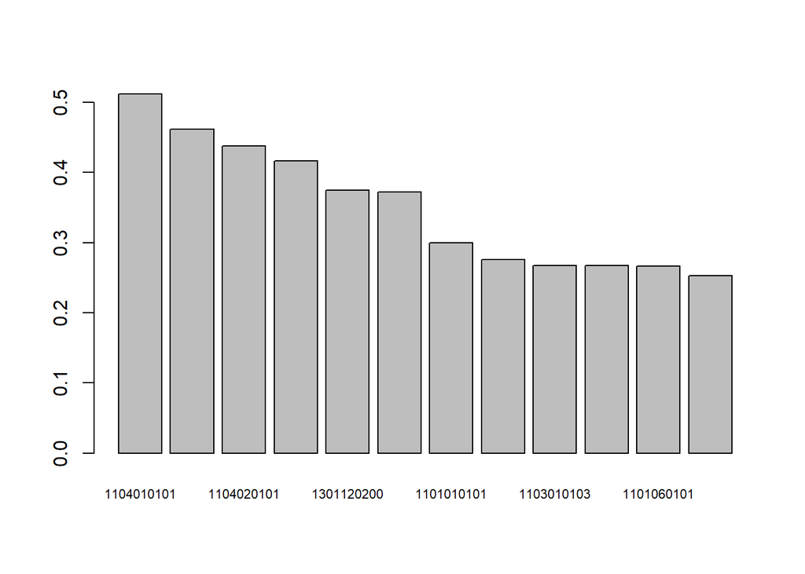

```r
headFreq = head(sort(itemFrequency(ttr), decreasing = TRUE), n=12)
headFreqDf = data.frame(keyName=names(headFreq), value=headFreq, row.names=NULL)
print(xtable(headFreqDf, type="latex"), file="tables\\mfitset_beforeapriori.tex")
barplot(headFreq, cex.names=0.7)
```

The most frequent item is the 1104010101, present in more than half of purchases (0.51) followed by 1301120101 and 1104020101. The maxlen parameters has not been applied yet but will be for the association rules analysis.

## Apriori application

```r
ap <- apriori(ttr, parameter=list(support=0.001, confidence=0.1, maxlen=5))
```

```
## Apriori
##
## Parameter specification:
##  confidence minval smax arem  aval originalSupport maxtime support minlen
##         0.1    0.1    1 none FALSE            TRUE       5   0.001      1
##  maxlen target  ext
##       5  rules TRUE
##
## Algorithmic control:
##  filter tree heap memopt load sort verbose
##     0.1 TRUE TRUE  FALSE TRUE    2    TRUE
##
## Absolute minimum support count: 20
##
## set item appearances ...[0 item(s)] done [0.00s].
## set transactions ...[858 item(s), 20082 transaction(s)] done [0.16s].
## sorting and recoding items ... [806 item(s)] done [0.02s].
## creating transaction tree ... done [0.01s].
## checking subsets of size 1 2 3 4
```

```
##  done [8.72s].
## writing ... [17365920 rule(s)] done [2.32s].
## creating S4 object  ... done [5.73s].
```

```r
summary(ap)
```

```
## set of 17365920 rules
##
## rule length distribution (lhs + rhs):sizes
##        1        2        3        4
##       70    60298  2490611 14814941
##
##    Min. 1st Qu.  Median    Mean 3rd Qu.    Max.
##    1.00    4.00    4.00    3.85    4.00    4.00
##
## summary of quality measures:
##     support           confidence        coverage             lift
##  Min.   :0.001046   Min.   :0.1000   Min.   :0.001046   Min.   :  0.2424
##  1st Qu.:0.001195   1st Qu.:0.1899   1st Qu.:0.003585   1st Qu.:  1.3230
##  Median :0.001494   Median :0.2958   Median :0.005826   Median :  1.6535
##  Mean   :0.002060   Mean   :0.3324   Mean   :0.007957   Mean   :  1.9214
##  3rd Qu.:0.002191   3rd Qu.:0.4527   3rd Qu.:0.009461   3rd Qu.:  2.1873
##  Max.   :0.511752   Max.   :1.0000   Max.   :1.000000   Max.   :153.1960
##      count
##  Min.   :   21.00
##  1st Qu.:   24.00
##  Median :   30.00
##  Mean   :   41.38
##  3rd Qu.:   44.00
##  Max.   :10277.00
##
## mining info:
##  data ntransactions support confidence
##   ttr         20082   0.001        0.1
##                                                                                  call
##  apriori(data = ttr, parameter = list(support = 0.001, confidence = 0.1, maxlen = 5))
```

### Most frequent itemsets (after filtering)

```r
fsets <- unique(generatingItemsets(ap))
fsets.df <- as(fsets, "data.frame")
sor.fsets <- fsets.df[order(-fsets.df$support),]
sor.fsets[1:12,]
```

```
##                         items   support
## 69               {1104010101} 0.5117518
## 70               {1301120101} 0.4618564
## 68               {1104020101} 0.4379544
## 67               {1103010101} 0.4160940
## 66               {1301120200} 0.3742655
## 65               {1104040101} 0.3720247
## 64               {1101010101} 0.2998705
## 60               {1301010101} 0.2757195
## 58               {1103010103} 0.2673041
## 63               {1301110301} 0.2670053
## 62               {1101060101} 0.2667563
## 60355 {1301120101,1301120200} 0.2599841
```

```r
print(xtable(sor.fsets[1:12,], type="latex"), file="tables\\mfitset_afterapriori.tex")
```

The 10 most frequent itemsets are single-item sets, which means that they are more likely to appear than any other itemset (single or multiple). It is also interesting to notice that the filtering we applied on the data (using support, confidence and maxlen parameters) had no influence on the top 10 items (being itemsets after apriori).

However, if we dig further, we can see that the 12th most frequent itemset is containing 2 items (1301120101,1301120200 with a support of 0.26) which is actually composed of the 2nd and 5th most frequent (single-item) itemsets.

## Sorted rules

### Rules sorted by lift

Let’s know comapre rules in the lift criteria which quantifies how much better the rule is than a random prediction. A lift higher than 1 means that the rule is indeed reliable to make a prediction when a lift lower than 1 means that a random prediction is better than the rule, which makes it non-relevent.

```r
lifted <- sort(ap, by="lift")
inspect(lifted[1:3])
```

```
##     lhs                                     rhs          support     confidence
## [1] {1302140800}                         => {1302140700} 0.001145304 0.5111111
## [2] {1302140700}                         => {1302140800} 0.001145304 0.3432836
## [3] {1203140500, 1205020300, 1206010301} => {1201020404} 0.001045713 0.9130435
##     coverage    lift    count
## [1] 0.002240813 153.196 23
## [2] 0.003336321 153.196 23
## [3] 0.001145304 143.248 21
```

```r
print(xtable(inspect(lifted[1:3]), type="latex"), file="tables\\top_rules_lift.tex")
```

```
##     lhs                                     rhs          support     confidence
## [1] {1302140800}                         => {1302140700} 0.001145304 0.5111111
## [2] {1302140700}                         => {1302140800} 0.001145304 0.3432836
## [3] {1203140500, 1205020300, 1206010301} => {1201020404} 0.001045713 0.9130435
##     coverage    lift    count
## [1] 0.002240813 153.196 23
## [2] 0.003336321 153.196 23
## [3] 0.001145304 143.248 21
```

We can see that those three rules have a very high lift (around 150) which means that we are able to predict the right-hand side element (for example 1302140700 for the first rule) using this rule.